# Twitter Analysis

Divya

5 1 2020

## Twitter Analysis

What kind of data do you expect to get? How is it different from what we have been doing till now? What about text? How do you think that works? Has anyone worked with text before?

### First we get packages

If you do not already have them, install and load the following packages

```r
library(tidyverse)
library(tm)
library(rtweet)
```

```r
library(wordcloud2)
library(tidytext)
```

### What kind of data can we get using the ‘rtweet’ package?

We will try and do three basic things. 1. Get the last 1000 tweets for #rstats 2. get the last 200 tweets the R-Ladies Freiburg account marked as favourites 3. Try and plot when the #rstats tweets were most active

You can check the [rtweet info](https://rtweet.info/)for more functions you can use.

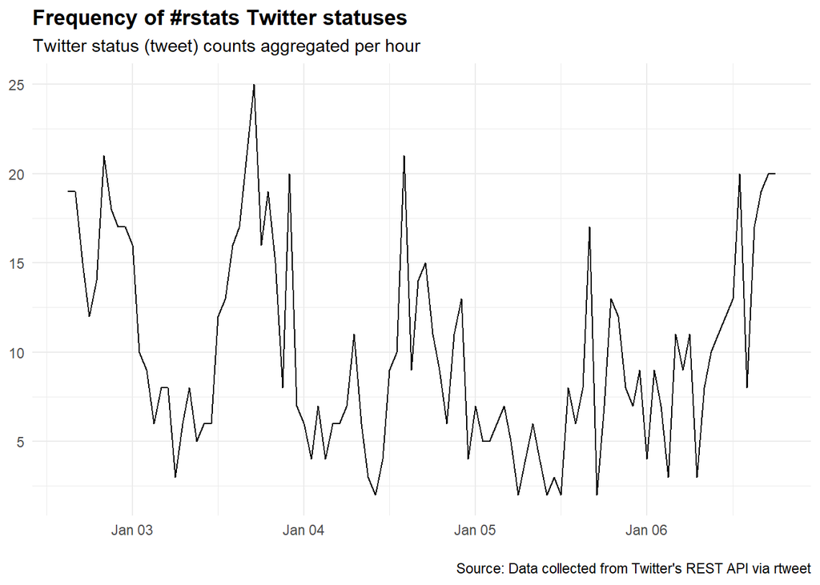

```r
#Using the search_tweets function
rstats_tweets <- search_tweets("#rstats", n = 1000, include_rts = FALSE) ## Please reduce this number if you think your laptop won't be able to handle it

#Using get_favourites
what_we_like <- get_favorites("rladiesfreiburg", n = 200)

## plot time series of tweets
rstats_tweets %>%
  ts_plot("1 hours") +
  ggplot2::theme_minimal() +
  ggplot2::theme(plot.title = ggplot2::element_text(face = "bold")) +
  ggplot2::labs(
    x = NULL, y = NULL,
    title = "Frequency of #rstats Twitter statuses",
    subtitle = "Twitter status (tweet) counts aggregated per hour",
    caption = "\nSource: Data collected from Twitter's REST API via rtweet"
  )
```

Question - will you get the same plot everytime to run this code?

### Now lets try and analyse the actual text of the tweets

```r
tweets <- search_tweets("#HappyNewYear2020", n = 200, include_rts = FALSE)
text <- tweets$text
# Create a corpus
docs <- Corpus(VectorSource(text))
docs <- docs %>%
  tm_map(removeNumbers) %>%
  tm_map(removePunctuation) %>%
  tm_map(stripWhitespace)
docs <- tm_map(docs, removeWords, stopwords("english"))
dtm <- TermDocumentMatrix(docs)
matrix <- as.matrix(dtm)
words <- sort(rowSums(matrix),decreasing=TRUE)
df <- data.frame(word = names(words),freq=words)
```

### Wordclouds

Now we have the text as separate words and their frequencies. How do we visualize this?

```r
wordcloud2(data=df, size=2.5, color='random-dark')
```

[interactive chart not shown]

How do you find the wordcloud? It also tells you the frequency of words! But - It still requires a lot more cleaning! What all do we have to consider? We could go on with differs… There are a host of things available online.

### Sentiment Analysis.

There are a number of lexicon used for sentiment analysis - some have categories, some have ratings. We’ll look at the ‘tidytext’ package today which has three possibilities

1. AFINN from Finn Årup Nielsen,
2. bing from Bing Liu and collaborators, and
3. nrc from Saif Mohammad and Peter Turney.

Let’s try the nrc lexicon today. We will match our works with the words in the lexicon and select those classified as ‘possitive’.

```r
nrc <- get_sentiments("nrc") %>%
  filter(sentiment == "positive")

PositiveWords<-df %>%
  inner_join(nrc)
PositiveWords<-as.data.frame(PositiveWords)
```

```r
wordcloud2(data=PositiveWords, size=2.5, color='random-dark')
```

[interactive chart not shown]